# Classes and methods for spatial data in R

Abstract

“Classes and methods for spatial data in R” published in R News.

R has been used for spatial statistical analysis for a long time: packages dedicated to several areas of spatial statistics have been reviewed in Bivand and Gebhardt (2000) and Ripley (2001), and more recent packages have been published (Ribeiro and Diggle, 2001; Pebesma, 2004; Baddeley and Turner, 2005). In addition, R links to GIS have been developed (Bivand, 2000, 2005; Gómez-Rubio and López-Quílez, 2005). A **task view** of spatial statistical analysis is being maintained on CRAN.

Many of the spatial packages use their own data structures (classes) for the spatial data they need or create, and provide methods, e.g. for plotting them. However, up to now R has been lacking a full-grown coherent set of classes and methods for the major spatial data types: points, lines, polygons, and grids. Package **sp**, available on CRAN since May 2005, has the ambition to fill this gap.

We believe there is a need for **sp** because

1. $i$ with support for a single package for spatial data, it is much easier to go from one spatial statistics package to another. Its classes are either supported directly by the packages, reading and writing data in the new spatial classes, or indirectly e.g. by supplying data conversion between **sp** and the package in an interface package. This requires one-to-many links, which are easier to provide and maintain than many-to-many links,
2. $ii$ the new package provides a well-tested set of methods (functions) for plotting, printing, subsetting and summarizing spatial objects, or combining (overlay) spatial data types,
3. $iii$ packages with interfaces to GIS and geographic (re)projection code support the new classes,
4. $iv$ the new package provides Lattice plots, conditioning plots, plot methods that combine points, lines, polygons and grids with map elements (reference grids, scale bars, north arrows), degree symbols (52°N) in axis labels, etc.

This article introduces the classes and methods provided by **sp**, discusses some of the implementation details, and the state and potential of linking **sp** to other packages.

## Classes and implementation

The spatial classes in **sp** include points, lines, polygons and grids; each of these structures can have multiple attribute variables, describing what is actually registered (e.g. measured) for a certain location or area. Single entries in the attribute table may correspond to multiple lines or polygons; this is useful because e.g. administrative regions may consist of several polygons (mainland, islands). Polygons may further contain holes (e.g. a lake), polygons in holes (island in lake), holes in polygons in holes, etc. Each spatial object registers its coordinate reference system when this information is available. This allows transformations between latitude/longitude and/or various projections.

The **sp** package uses S4 classes, allowing for the validation of internal consistency. All Spatial classes in **sp** derive from an abstract class `Spatial`, which only holds a bounding box and the projection or coordinate reference system. All classes are S4 classes, so objects may be created by function `new`, but we typically envisage the use of helper functions to create instances. For instance, to create a `SpatialPointsDataFrame` object from the `meuse` data.frame, we might use:

```
> library(sp)
> data(meuse)
> coords = SpatialPoints(meuse[c("x", "y")])
> meuse = SpatialPointsDataFrame(coords, meuse)
> plot(meuse, pch=1, cex = .05*sqrt(meuse$zinc))
```

the plot of which is shown in figure 1.

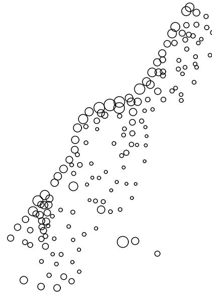

Figure 1: Bubble plot of top soil zinc concentration

The function `SpatialPoints()` creates a `SpatialPoints` object. `SpatialPointsDataFrame()` merges this object with an attribute table to creates an object of class `SpatialPointsDataFrame`.

| data type | class | attributes | extends |
| --- | --- | --- | --- |
| points | SpatialPoints | none | Spatial* |
| points | SpatialPointsDataFrame | AttributeList | SpatialPoints* |
| pixels | SpatialPixels | none | SpatialPoints* |
| pixels | SpatialPixelsDataFrame | AttributeList | SpatialPixels* SpatialPointsDataFrame** |
| full grid | SpatialGrid | none | SpatialPixels* |
| full grid | SpatialGridDataFrame | AttributeList | SpatialGrid* |
| line | Line | none |  |
| lines | Lines | none | Line list |
| lines | SpatialLines | none | Spatial*, Lines list |
| lines | SpatialLinesDataFrame | data.frame | SpatialLines* |
| polygon | Polygon | none | Line* |
| polygons | Polygons | none | Polygon list |
| polygons | SpatialPolygons | none | Spatial*, Polygons list |
| polygons | SpatialPolygonsDataFrame | data.frame | SpatialPolygons* |

* by direct extension; ** by setIs() relationship;

Table 1: Overview of the spatial classes provided by **sp**. Classes with topology only are extended by classes with attributes.

An alternative to the calls to `SpatialPoints()` and `SpatialPointsDataFrame()` above is to use `coordinates<-`, as in

```
> coordinates(meuse) = c("x", "y")
```

Reading polygons from a shapefile (a commonly used format by GIS) can be done by the `readShapePoly` function in **maptools**, which depends on **sp**. It returns an object of class `SpatialPolygonsDataFrame`, for which the `plot` method is in **sp**. An example that uses a shapefile provided by package **maptools** is:

```
> library(maptools)
> fname = system.file("shapes/sids.shp",
+   package="maptools")
> p4s = CRS("+proj=longlat +datum=NAD27")
> nc = readShapePoly(fname, proj4string=p4s)
> plot(nc, axes = TRUE, col=grey(1-nc$SID79/57))
```

for which the plot is shown in figure 2. The function `CRS` defines the coordinate reference system.

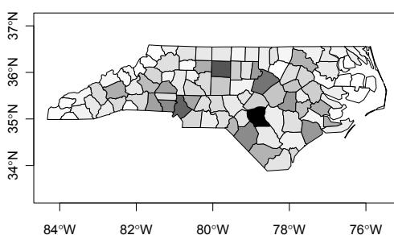

Figure 2: North Carolina sudden infant death (SID) cases in 1979 (white 0, black 57)

An overview of the classes for spatial data in **sp** is given in Table 1. It shows that the points, pixels and grid classes are highly related. We decided to implement two classes for gridded data: `SpatialPixels` for unordered points on a grid, `SpatialGrid` for a full ordered grid, e.g. needed by the `image` command. `SpatialPixels` store coordinates but may be efficient when a large proportion of the bounding box has missing values because it is outside the study area (‘sparse’ images).

A single `Polygons` object may consist of multiple `Polygon` elements, which could be islands, or holes, or islands in holes, etc. Similarly, a `Lines` entity may have multiple `Line` segments: think of contour lines as an example.

This table also shows that several classes store their attributes in objects of class `AttributeList`, instead of `data.frames`, as the class name would suggest. An `AttributeList` acts mostly like a `data.frame`, but stores no `row.names`, as row names take long to compute and use much memory to store. Consider the creation of a $1000 \times 1000$ grid:

```
> n = 1000
> df = data.frame(expand.grid(x=1:n, y=1:n),
+   z=rnorm(n * n))
> object.size(df)
[1] 56000556 # mostly row.names!
> library(sp)
> coordinates(df) = ~x+y
> object.size(df)
[1] 16002296 # class SpatialPointsDataFrame
> gridded(df) = TRUE
> object.size(df)
[1] 20003520 # class SpatialPixelsDataFrame
> fullgrid(df) = TRUE
> object.size(df)
[1] 8003468 # class SpatialGridDataFrame
```

Using `data.frame` as attribute tables for moderately sized grids (e.g. Europe on a $1 \text{ km} \times 1 \text{ km}$ grid) became too resource intensive on a computer with 2 Gb RAM, and we decided to leave this path.

| method | what it does |
| --- | --- |
| [ | select spatial items (points, lines, polygons, or rows/cols from a grid) and/or attributes variables |
| $, $<-, [[, [[<- | retrieve, set or add attribute table columns |
| spsample | sample points from a set of polygons, on a set of lines or from a gridded area, using the simple sampling methods given in Ripley (1981) |
| spplot | lattice (Trellis) plots of spatial variables (figure 3; see text) |
| bbox | give the bounding box |
| proj4string | get or set the projection (coordinate reference system) |
| coordinates | set or retrieve coordinates |
| polygons | set or retrieve polygons |
| gridded | verify whether an object is a grid, or convert to a gridded format |
| dimensions | get the number of spatial dimensions |
| coerce | convert from one class to another |
| transform | (re-)project spatial coordinates (uses spproj) |
| overlay | combine two different spatial objects (see text) |
| recenter | shift or re-center geographical coordinates for a Pacific view |

Table 2: Methods provided by package **sp**

For classes `SpatialLinesDataFrame` and `SpatialPolygonsDataFrame` we expect that the spatial entities corresponding to each row in the attribute table dominate memory usage; for the other classes it is reversed. If row names are needed in a points or gridded data structure, they must be stored as a (character) attribute column.

`SpatialPolygons` and `SpatialLines` objects have IDs stored for each entity. For these classes, the ID is matched to attribute table IDs when a `Spatial*DataFrame` object is created. For points, IDs are matched when present upon creation. If the matrix of point coordinates used in creating a `SpatialPointsDataFrame` object has rownames, these are matched against the data frame row.names, and subsequently discarded. For points and both grid classes IDs are not stored because, for many points, this wastes processing time and memory. ID matching is an issue for lines and polygons when topology and attributes often come from different sources (objects, files). Points and grids are usually created from a single table, matrix, or array.

## Methods

Beyond the standard `print`, `plot` and `summary` methods, methods that **sp** provides for each of the classes are shown in table 2.

Some of these methods are much for user convenience, to make the spatial data objects behave just like `data.frame` objects where possible; others are specific for spatial topology. For example, the overlay function can be used to retrieve the polygon information on point locations, or to retrieve the information for a collection of points falling inside each of the polygons. Alternatively, points and grid cells may be overlayed, resulting in a point-in-gridcell operation. Other overlay methods may be implemented when they seem useful. Method `summary` shows the data class, bounding box, projection information, number of spatial entities, and a summary of the attribute table if present.

### Trellis maps

When plotting maps one usually needs to add spatial reference elements such as administrative boundaries, coastlines, cities, rivers, scale bars or north arrows. Traditional plots allow the user to add components to a plot, by using `lines`, `points`, `polygon` or `text` commands, or by using `add=TRUE` in `plot` or `image`. Package **sp** provides traditional plot methods for e.g. `points`, `lines` and `image`, but has in addition an `spplot` command which lets you plot Trellis plots (provided by the **lattice** package) to produce plots with multiple maps. Method `spplot` allows for addition of spatial elements and reference elements on all or a selection of the panels.

The example in figure 3 is created by:

```
> arrow = list("SpatialPolygonsRescale",
+   layout.north.arrow(2),
+   offset = c(-76,34), scale = 0.5, which=2)
> spplot(nc, c("SID74","SID79"),as.table=TRUE,
+   scales=list(draw=T), sp.layout = arrow)
```

where the `arrow` object and `sp.layout` argument ensure the placement of a north arrow in the second panel only.

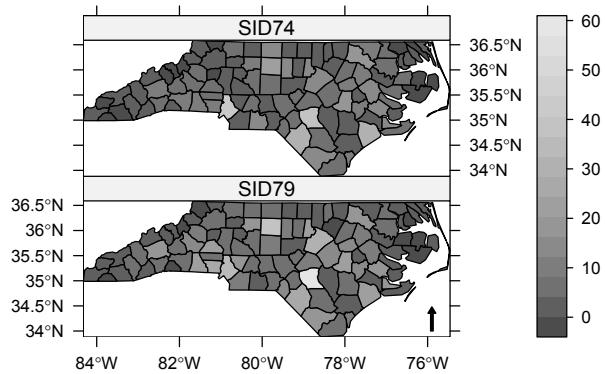

Figure 3: Trellis graph created by spplot

## Connections to GIS

On the R-spatial web site (see below) a number of additional packages are available, linking **sp** to several external libraries or GIS:

**spproj** allows (re)projection of **sp** objects, **spgpc** allows polygon clipping with **sp** objects, and can e.g. check whether polygons have holes, **spgrass6** read and write **sp** objects from and to a GRASS 6.0 data base, **spgdal** read and write **sp** objects from gdal data sets: it provides a “[” method that reads in (part of) a gdal data and returns an **sp** grid object.

It is not at present likely that a single package for interfacing external file and data source formats like the recommended package **foreign** will emerge, because of large and varying external software dependencies.

## Connections to R packages

CRAN packages maintained by the **sp** authors do already use **sp** classes: package **maptools** has code to read shapefiles and Arc ASCII grids into **sp** class objects, and to write **sp** class objects to shapefiles or Arc ASCII grids. Package **gstat** can deal with points and grids, and will compute irregular block kriging estimates when a polygons object is provided as new-data (prediction ‘regions’).

The **splancs**, **DCluster**, and **spdep** packages are being provided with ways of handling **sp** objects for analysis, and **RArcInfo** for reading ArcInfo v. 7 GIS binary vector E00 files.

Interface packages present which convert to or from some of the data structures adopted by spatial statistics packages include **spPBS**, **spmaps**; packages under development are **spspatstat**, **spgeoR**, **spfields** and **spRandomFields**. These interface packages depend on both **sp** and the package they interface to, and provide methods to deal with **sp** objects in the target functions. Whether to introduce dependence on **sp** into packages is of course up to authors and maintainers. The interface framework, with easy installation from the R-spatial repository on SourceForge (see below), is intended to help users who need **sp** facilities in packages that do not use **sp** objects directly — for example creating an observation window for **spatstat** from polygons read from a shapefile.

## Further information and future

The R-spatial home page is http://r-spatial.sourceforge.net/

Announcements related to **sp** and interface packages are sent to the **R-sig-geo** mailing list.

A first point for obtaining more information on the classes and methods in **sp** is the package vignette. There is also a demo, obtained by which gives the plots of the gallery also present at the R-spatial home page.

```
> library(sp)
> demo(gallery)
```

Development versions of **sp** and related packages are on cvs on sourceforge, as well as interface packages that are not (yet) on CRAN. An off-CRAN package repository with source packages and Windows binary packages is available from sourceforge as well, so that the package installation should be sufficiently convenient before draft packages reach CRAN:

```
> rSpatial = "http://r-spatial.sourceforge.net/R"
> install.packages("spproj", repos=rSpatial)
```

## Acknowledgements

The authors want to thank Barry Rowlingson (whose ideas inspired many of the methods now in **sp**, see Rowlingson et al. (2003)), and Virgilio Gómez-Rubio.

## References

- A. Baddeley and R. Turner. Spatstat: an R package for analyzing spatial point patterns. *Journal of Statistical Software*, 12(6):1–42, 2005. URL: www.jstatsoft.org, ISSN: 1548-7660.
- R. Bivand. Interfacing GRASS 6 and R. *GRASS Newsletter*, 3:11–16, June 2005. ISSN 1614-8746.
- R. Bivand. Using the R statistical data analysis language on GRASS 5.0 GIS data base files. *Computers & Geosciences*, 26:1043–1052, 2000.
- R. Bivand and A. Gebhardt. Implementing functions for spatial statistical analysis using the R language. *Journal of Geographical Systems*, 3(2):307–317, 2000.
- V. Gómez-Rubio and A. López-Quílez. RArcInfo: using GIS data with R. *Computers & Geosciences*, 31: 1000–1006, 2005.
- E. Pebesma. Multivariable geostatistics in S: the gstat package. *Computers & Geosciences*, 30:683–691, 2004.
- P. Ribeiro and P. Diggle. geoR: A package for geostatistical analysis. *R-News*, 1(2), 2001. URL: www.r-project.org, ISSN: 1609-3631.
- B. Ripley. Spatial statistics in R. *R-News*, 1(2), 2001. URL: www.r-project.org, ISSN: 1609-3631.
- B. Ripley. *Spatial Statistics*. Wiley, New York, 1981.
- B. Rowlingson, A. Baddeley, R. Turner, and P. Diggle. Rasp: A package for spatial statistics. In A. Z. K. Hornik, F. Leisch, editor, *Proceedings of the 3rd International Workshop on Distributed Statistical Computing (DSC 2003), March 20–22, Vienna, Austria.*, 2003. ISSN 1609-395X.